# Day 11 Exercise

```r
glance(model)
```

```
# A tibble: 1 × 12
  r.squared adj.r.squared sigma statistic  p.value    df logLik   AIC   BIC
      <dbl>         <dbl> <dbl>     <dbl>    <dbl> <dbl>  <dbl> <dbl> <dbl>
1     0.609         0.595  21.2      41.3 7.68e-21     4  -494. 1000. 1016.
# ℹ 3 more variables: deviance <dbl>, df.residual <int>, nobs <int>
```

14. Interpret the model summary output (coefficients, R-squared, p-values) in plain language. The summary output of the model suggests that this model accounts for approximately 61% of all variance observed in the data and, given the extremely small p-value, it is unlikely that model doesn’t fit the data. As for coefficients, we can see that Temperarture will have the greates positive influence on ozen concentrations, with solar radiation and the season having a smaller positive influence
15. Use broom::augment to supplement the normalized data.frame with the fitted values and residuals.

```r
augment <- augment(model)
```

16. Extract the residuals and visualize their distribution as a histogram and qqplot.

```r
hist <- gghistogram(augment$.resid, y = "density",
            bins = 30, fill = "skyblue",
            add = "mean",
            main = "Histogram of Residual Distribution",
            color = "black", add_density = TRUE)
qq <- ggqqplot(x = '.resid', augment)
```

17. Use ggarange to plot this as one image and interpret what you see in them.  
    The histogram and q-q plot suggest that the data is roughly normally distributed, but has a slight right skew, with many outliers concentrated in the higher values that deviate from normality.

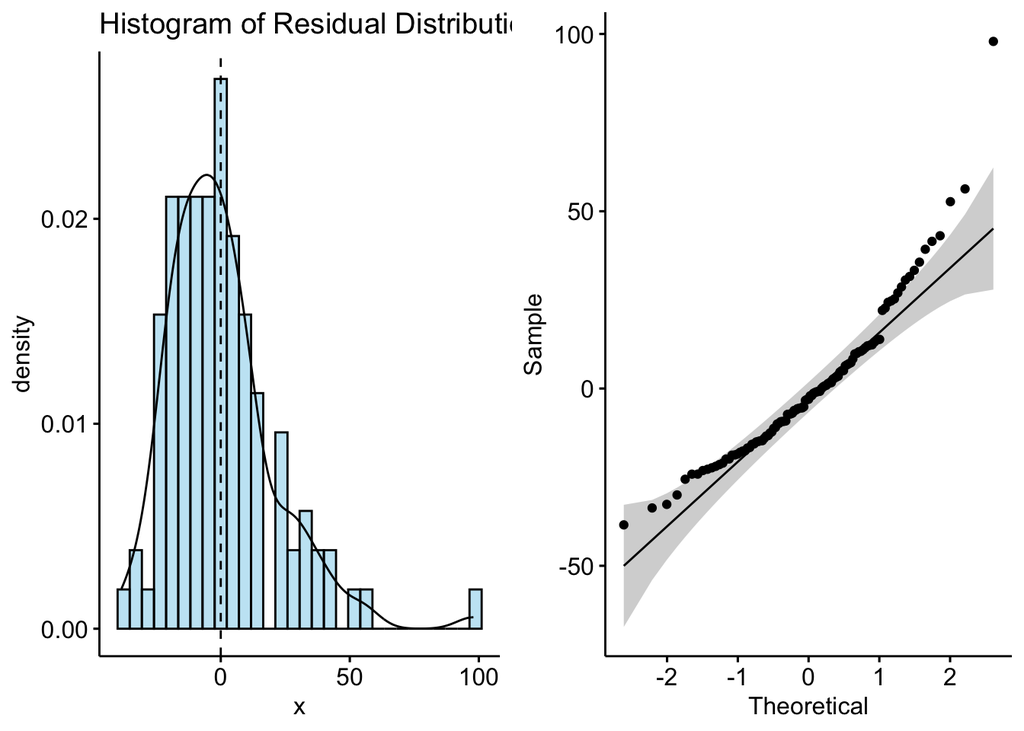

```r
ggarrange(hist, qq)
```

18. Create a scatter plot of actual vs. predicted values using ggpubr with the following setting:

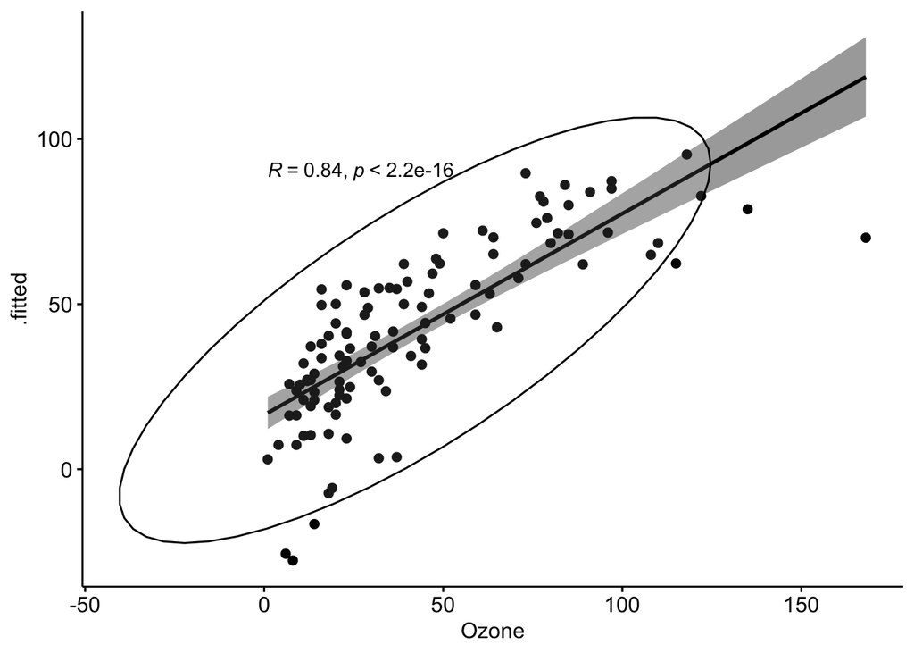

```r
ggscatter(augment, x = "Ozone", y = ".fitted",
          add = "reg.line", conf.int = TRUE,
          cor.coef = TRUE, cor.method = "spearman",
          ellipse = TRUE)
```

19. How strong of a model do you think this is?  
    Given a relatively high R value and a low p-value, this is probably a decent model, especially when predicting values closer to the mean. However, the slight right skew of the data suggests that this model may be less effective and accurate at predicting high and low ozone concentrations. Overall, while this model is reasonably good, their may be other, nonlinear models that fit the data better.